# Test Report

Michal

Last edited: 2021 11 15

# 1 header 1

## 1.1 header 2

### 1.1.1 header 3

Adding sentenses is simple, such as adding `highlighted text` or `inline text`

Every new continous line acts as new sentense.

Formatting text: **bold** or **bold** *italics* or *italics* strikethrought

Also adding [links to websites](https://www.google.co.uk) or links directly https://www.google.co.uk Add images like this

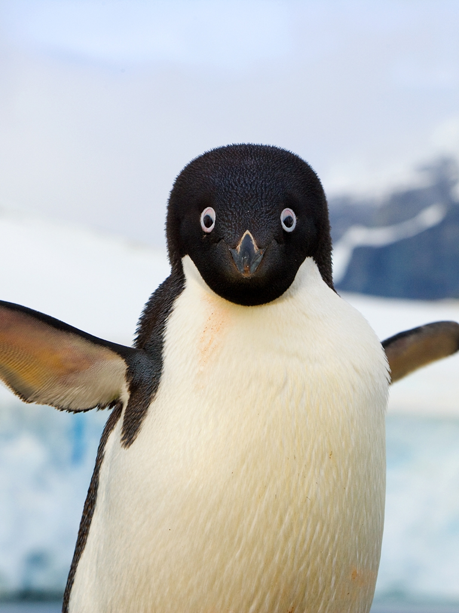

#### 1.1.1.1 bulleted lists

1. A list
- list
  - item
    - item2
  - item3
2. still list

## 1.2 R Markdown

```r
# Text in code chunk
print("Hello World")
```

```
## [1] "Hello World"
```

```r
print("To make new chunk use 'ctrl alt I'")
```

```
## [1] "To make new chunk use 'ctrl alt I'"
```

```r
x <- "variable"
```